# Introduccion a visualizaciones en R

# 8 Bonus

Quieren darle un aspecto un poco diferente a sus gráficos? Pueden probar utilizando temas. Es muy simple, se agregan simplemente como una capa más.

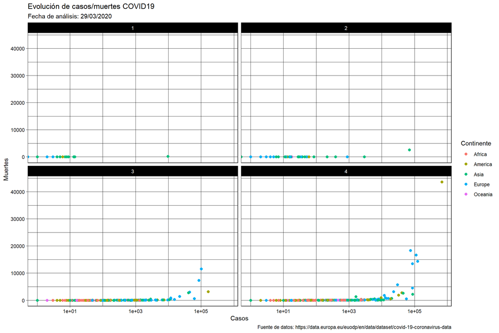

```r
ggplot (data = coronavirus_agrupado, aes(x=casos, y=muertes)) +
        geom_point(size = 2, aes(color = continentExp)) +
        scale_x_log10() +
        facet_wrap(~month) +
        labs ( title = "Evolución de casos/muertes COVID19",
               subtitle = "Fecha de análisis: 29/03/2020",
               x = "Casos",
               y = "Muertes",
               color = "Continente",
               caption = "Fuente de datos: https://data.europa.eu/euodp/en/data/dataset/covid-19-coronavirus-data") +
        theme_linedraw()
```

Como si esto no fuera poco, pueden agregar más temas instalando otras librerías! install.packages(“ggthemes”)

```r
library(ggthemes)
```

Veamos alguno de los temas descargados.

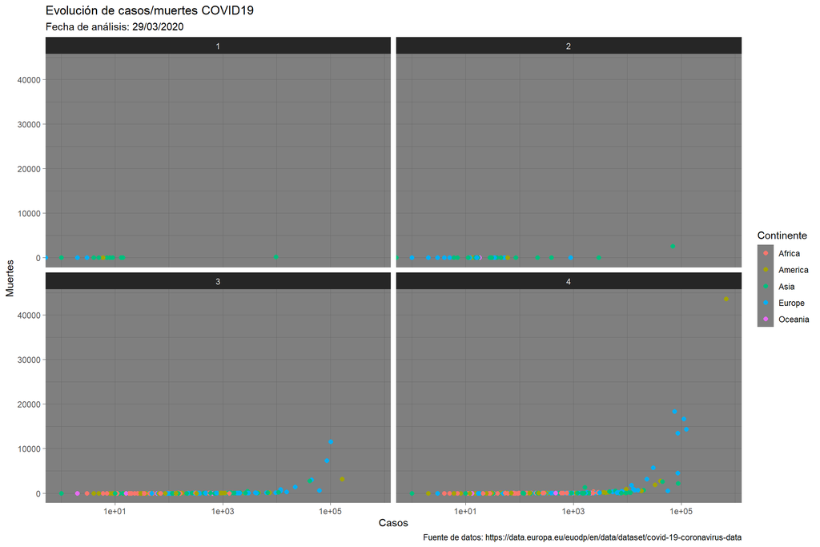

```r
ggplot (data = coronavirus_agrupado, aes(x=casos, y=muertes)) +
        geom_point(size = 2, aes(color = continentExp)) +
        scale_x_log10() +
        facet_wrap(~month) +
        labs ( title = "Evolución de casos/muertes COVID19",
               subtitle = "Fecha de análisis: 29/03/2020",
               x = "Casos",
               y = "Muertes",
               color = "Continente",
               caption = "Fuente de datos: https://data.europa.eu/euodp/en/data/dataset/covid-19-coronavirus-data") +
        theme_dark()
```

También pueden dar un vistazo al sitio https://www.data-to-viz.com/. Es un sitio que contiene muchas visualizaciones, con su respectivo código en R, para que puedan copiar gráficos parecidos.

Y por último, siempre es recomendable revisar el **cheatsheet** de ggplot, en el link que les dejamos la clase pasada.

https://rstudio.com/resources/cheatsheets/